# Faith2ax：老忠實案例策略分析

中山大學管理學院 卓雍然

2022-03-25 17:48:56

### 1. 參考程式

```r
#rm(list=ls(all=T))
head(faithful)          # load data and
```

```
  eruptions waiting
1     3.600      79
2     1.800      54
3     3.333      74
4     2.283      62
5     4.533      85
6     2.883      55
```

```r
D = faithful$eruptions  # copy it to a short name
```

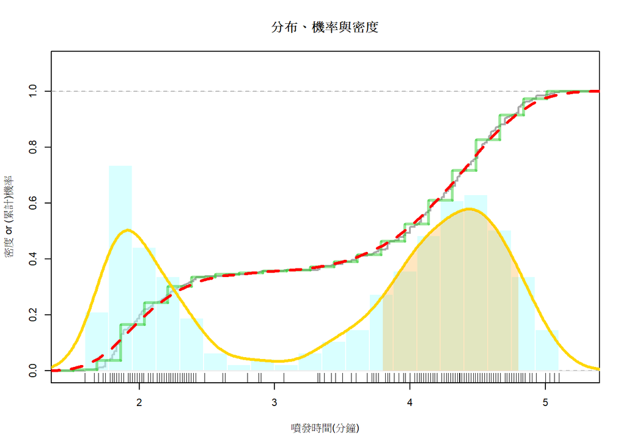

```r
##### 先畫一個圖框
par(cex=0.7)
plot(0,0,xlim=c(1.5,5.25),ylim=c(0,1.1),xlab="噴發時間(分鐘)",
     ylab="密度 or (累計)機率", main="分布、機率與密度")
abline(h=1, col='lightgray', lwd=0.25, lty=2)


##### 數值標記
# Empirical Rug PDF, 實證(數值標記)機率密度函數
rug(D)
# Empirical CDF, 實證(數值標記)累計機率密度函數
plot(ecdf(D), cex=0, verticals=T, lwd=2, col='darkgray', add=T)


##### Histogram PDF 直方圖機率密度函數
Bins = 20                               # no. bins
bx = seq(min(D), max(D), length=Bins+1) # break sequence
hist(D, col="#B3FFFF7F", border="white",
     freq=F, breaks=bx, add=T)
abline(h=0, col='lightgray', lwd=0.25)
# Histogram CDF
adj = (bx[2] - bx[1])/2
steps = stepfun(bx-adj, c(0, sapply(bx, function(b) mean(D <= b)))) #階梯函數
plot(steps, cex=0, col='#33CC337F', lwd=3, lty=1, add=T)


##### Smooth PDF 平滑機率密度函數
Adjust = 0.5                       # set bandwidth (帶寬)
DEN = density(D, adjust = Adjust)  # create density function
lines(DEN, col='gold', lwd=3)

# Smooth CDF 畫出累計機率密度函數
PDF = approxfun(DEN$x, DEN$y, yleft=0, yright=0) #插值函數
x = seq(1,6,0.1)
y = sapply(x, function(i) integrate(PDF, -Inf, i)$value)
lines(x, y, col='red', lwd=3, lty=2)

##### 標示範圍[x1, x2]
x1 = 3.8; x2 = 4.8
 #rect(x1,-0.1,x2,1.2,col= rgb(0,1,0,alpha=0.2),border=NA) 畫長方形
x = seq(x1, x2, length=100)
polygon(c(x, x2, x1),  c(PDF(x), 0, 0), col="#FF99003F", border=NA)
```

使用PDF估計機率

```r
# Calculate Probability 算出範圍[x1, x2]的機率
(integrate(PDF, x1, x2)$value)
```

```
[1] 0.4755
```

### 2. 策略規劃

##### CASE-01

假如你是黃石公園的旅遊直昇機公司，你的業務需要預估老忠實下一次的噴發時間，假如現在的商業情境是：你可以花30元選定一個連續60秒的時段，如果老忠實下一次的噴發時間落在你指定的區間，你就可以贏到100元；請你使用頻寬為0.5的平滑密度模型 …

- 決定要不要參加這個賽局
- 如果你參加的話，你要把噴發時間設定在哪一個區間呢？
- 設在這個區間的話，你參加這個賽局的淨期望報償是？

```r
pacman::p_load(dplyr, ggplot2)
x1 = seq(0,5,0.1)
p = sapply(x1, function(x) (integrate(PDF, x, x+1)$value)) #算機率
data.frame(start=x1, stop=1+x1, p) %>% top_n(1, p)   #押每塊區間的機率再取最大
```

```
  start stop      p
1   3.9  4.9 0.4766
```

```r
#參加
#3.9 - 4.9 分
#(100*0.47.6) - 30 = 17.6 元
```

##### CASE-02

假如商業情境變成：從零開始把每10秒鐘設為一個區間，每個區間的賭金是五塊錢 …

- 你要怎麼押注，才能獲得最高的期望報償呢？
- 你的投資金額和期望報償各是多少？

```r
x = seq(1,6,1/6)  #10秒=1/6分鐘
cx = sapply(x, function(i) integrate(PDF, -Inf, i)$value)  #CDF
df = data.frame(
  start = x - 1/6, stop = x,
  prob=cx -lag(cx)            #全-上一個=剩10秒區域機率
  ) %>%
  mutate(payoff = 100*prob - 5)
bets = df %>% filter(payoff > 0) %>% arrange(start)  #payoff報償
bets
```

```
  start  stop    prob payoff
1 1.667 1.833 0.06366 1.3664
2 1.833 2.000 0.08226 3.2261
3 2.000 2.167 0.06967 1.9671
4 3.833 4.000 0.05836 0.8356
5 4.000 4.167 0.07652 2.6524
6 4.167 4.333 0.08932 3.9324
7 4.333 4.500 0.09576 4.5763
8 4.500 4.667 0.08938 3.9375
9 4.667 4.833 0.06844 1.8437
```

```r
#正期望報酬相加-->最大、最高的期望報償
```

```r
nrow(bets)         #要押幾注，Ans:9注，前提要有45塊
```

```
[1] 9
```

```r
5*nrow(bets)       #投資金額
```

```
[1] 45
```

```r
sum(bets$payoff)   #淨期望報償
```

```
[1] 24.34
```

```r
top_n(bets,4,payoff)$payoff %>% sum() #只有20元時的最佳淨期望報酬
```

```
[1] 15.67
```

##### CASE 03

將期望報償和投資金額的比值稱為「期望投資報酬率」 …

- 「最大期望投資報酬率」和「最大期望報酬」的投資策略是一樣的嗎？
- 你認為哪一個策略目標比較好呢？ 為什麼？

```r
#不一樣
#最大期望投資報酬率跟最大期望報酬的策略點不一定一樣
#各有所好，各有追求
#我選最大報酬，因為賺最多
```

```r
df = df %>% arrange(desc(payoff)) %>% mutate(
  n_bets = row_number(),       #看要押幾個
  c_invest = n_bets * 5,       #投資金額
  c_payoff = cumsum(payoff),   #累積報償
  c_ROI = c_payoff/c_invest    #投資報酬率 (賺/成本)
  ) %>% round(3)
head(df,20) %>% round(3)
```

```
   start  stop  prob payoff n_bets c_invest c_payoff  c_ROI
1  4.333 4.500 0.096  4.576      1        5    4.576  0.915
2  4.500 4.667 0.089  3.938      2       10    8.514  0.851
3  4.167 4.333 0.089  3.932      3       15   12.446  0.830
4  1.833 2.000 0.082  3.226      4       20   15.672  0.784
5  4.000 4.167 0.077  2.652      5       25   18.325  0.733
6  2.000 2.167 0.070  1.967      6       30   20.292  0.676
7  4.667 4.833 0.068  1.844      7       35   22.135  0.632
8  1.667 1.833 0.064  1.366      8       40   23.502  0.588
9  3.833 4.000 0.058  0.836      9       45   24.338  0.541
10 2.167 2.333 0.049 -0.095     10       50   24.242  0.485
11 4.833 5.000 0.041 -0.870     11       55   23.372  0.425
12 3.667 3.833 0.040 -1.005     12       60   22.367  0.373
13 2.333 2.500 0.030 -2.043     13       65   20.324  0.313
14 3.500 3.667 0.027 -2.290     14       70   18.034  0.258
15 1.500 1.667 0.027 -2.301     15       75   15.733  0.210
16 3.333 3.500 0.018 -3.183     16       80   12.550  0.157
17 5.000 5.167 0.018 -3.195     17       85    9.355  0.110
18 2.500 2.667 0.014 -3.557     18       90    5.799  0.064
19 3.167 3.333 0.010 -3.972     19       95    1.827  0.019
20 2.667 2.833 0.008 -4.213     20      100   -2.386 -0.024
```

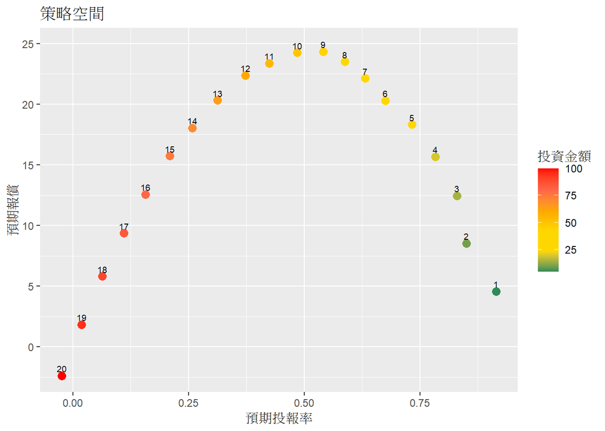

```r
ggplot(df[1:20,], aes(c_ROI, c_payoff, color=c_invest)) +
  geom_point(size=3) +
  geom_text(aes(label=n_bets), color='black', nudge_y=0.6, size=2.5) +
  scale_color_gradientn(colors=c('seagreen','gold','gold','orange','tomato','red')) +
  labs(title="策略空間",color="投資金額",y="預期報償",x="預期投報率")
```

🗿 **策略空間：**  
■ 如何畫策略空間？ 策略空間的主要功能是？  
■ 何謂效率前緣？ 何謂合理策略？  
🗿 **策略限制與權衡：**  
■ 如果沒有其它的投資機會，也沒有資金的限制，最佳的策略應該是？  
■ 如果你的資金上限是`c_invest <= 40`呢？  
■ 如果你有另外一個`ROI = 62.5%`的投資機會呢？

```r
#策略空間:利用預期報酬和預期投報率
#ggplot(df[1:20,], aes(c_ROI, c_payoff, color=c_invest)) + geom_point(size=3)
#功能:模擬所有策略，方便找合理，績效指標好的事件

#效率前緣:
#總風險相同時，相對上可獲得最高的預期報酬率 #預期報酬相同時，相對上總風險最低的投資組合。

#合理策略:決策的合理性，就是在能評價行動結果的一定價值體系下，選擇恰當的代替行為

#選第9個策略
nrow(bets)
```

```
[1] 9
```

```r
#8
dim(df %>% filter(c_invest <= 40))[1]
```

```
[1] 8
```

```r
#7
dim(df %>% filter(c_ROI >= 0.625))[1]
```

```
[1] 7
```

🍭 學習重點：  
■ 資料分析的基礎：資料、統計量、圖形、模型  
■ 建立模型的步驟：模型形式、複雜度參數  
■ 模型是一種幫助我們在不確定下做決策的工具，有模型才能做量化的預測和估計  
■ 但是，預測並不等於決策，模型做完，商業分析才剛開始而已  
■ 商業分析的步驟：  
◇ 資料、模型  
◇ 條件、預測、模擬、策略目標  
◇ 策略目標視覺化、溝通、決策  
■ R語言可以串聯上述步驟，用資料裝配線來進行商業分析  
■ 決策是一個溝通的過程，視覺化提供一個溝通的基礎  
■ 策略空間：  
◇ 策略、績效指標  
◇ 效率前緣、合理策略  
◇ 策略限制、策略權衡